# Project5 - Group5

Nishanth Gandhidoss, Raghavendran Shankar

8 April 2017

## Part 1: Answer by Hand

For the first four problems you do not need to use R/Matlab/Python, rather this is showing you understand definitions, concepts, and how the algorithms work.

#### Question 1

**Text Mining**

Consider the following documents:

Doc 1: cat, cat, bat, rat, fat, cat Doc 2: mat, pat, bat, bat, bat, rat Doc 3: fat, rat, mat, pat, sat, cat

#### Question 1a

(4 points) Construct the Term Document Matrix

|  | Doc 1 | Doc 2 | Doc 3 |  |
| --- | --- | --- | --- | --- |
| bat | 1 | 3 | 0 |  |
| cat | 3 | 0 | 1 |  |
| fat | 1 | 0 | 1 |  |
| mat | 0 | 1 | 1 |  |
| pat | 0 | 1 | 1 |  |
| rat | 1 | 1 | 1 |  |
| sat | 0 | 0 | 1 |  |

#### Question 1b

(6 points) Construct the TF-IDF Matrix

Lets find the IDF value by using log10(N/dft)

[output not shown]

Now on multiplyting the probability of term frequency with IDF we get TF-IDF matrix which is shown below

|  | Doc 1 | Doc 2 | Doc 3 |  |
| --- | --- | --- | --- | --- |
| bat | 0.029 | 0.088 | 0 |  |
| cat | 0.088 | 0 | 0.029 |  |
| fat | 0.029 | 0 | 0.029 |  |
| mat | 0 | 0.029 | 0.029 |  |
| pat | 0 | 0.029 | 0.029 |  |
| rat | 0 | 0 | 0 |  |
| sat | 0 | 0 | 0.0795 |  |

#### Question 1c

(2 points) What is the term-document pair(s) with the highest TF-IDF value.

**The paris of (bat, Doc2) and (cat, Doc1) have the highest TF-IDF value**

#### Question 2

### Recommendation Systems

Consider the following ratings matrix:

|  | Avengers | Iron Man 3 | The Dark Knight Rises | Captain America 2 |
| --- | --- | --- | --- | --- |
| Ann | 3.5 | 3 | 5 | 3.5 |
| Ben | 5 | 2 | 3 | 3 |
| Chris | 4 | 2.5 | 4 | 4 |
| Dana | ?? | 3 | 4.5 | 2.5 |

#### Question 2a

(6 points) Fill in the missing rating for Dana using user-based collaborative filtering with k = 2 nearest neighbors using Manhattan distance to compare users. Indicate which other users are closest to Dana and the resulting rating calculated (use simple averaging of nearest neighbors).

**In order to find the missing rating using user-based collaborative filtering we need to know the distance(manhattan) with the neighbors for the missing user**

Manhattan: Take the sum of the absolute values of the differences of the coordinates.

For example, if x=(a,b)x=(a,b) and y=(c,d)y=(c,d), the Manhattan distance between xx and yy is

[output not shown]

**Ann ~ Diana**

Distance between Ann and Diana = |3 - 3| + |5 - 4.5| + |3.5 - 2.5|

= 0 + 0.5 + 1

= 1.5

**Ben ~ Diana**

= 1 + 1.5 + 0.5

= 3

**Chris ~ Diana**

Distance between Chris and Diana = |2.5 - 3| + |4 - 4.5| + |4 - 2.5|

= 0.5 + 0.5 + 1.5

= 2.5

From the above calculations it looks like Chris and Ann are the two closest neighboors to Diana. So the missing rating will be average of ratings of both Chris and Ann ie) (3.5 + 4)/2 = 3.75

|  | Avengers | Iron Man 3 | The Dark Knight Rises | Captain America 2 |
| --- | --- | --- | --- | --- |
| Ann | 3.5 | 3 | 5 | 3.5 |
| Ben | 5 | 2 | 3 | 3 |
| Chris | 4 | 2.5 | 4 | 4 |
| Dana | **3.75** | 3 | 4.5 | 2.5 |

#### Question 2b

(6 points) Fill in the missing rating using item-based collaborative filtering with k = 2 nearest neighbors using Manhattan distance to compare items. Indicate which other items are closest to Avengers and the resulting rating calculated (use simple averaging of nearest neighbors).

**In order to find the missing rating using item-based collaborative filtering we need to know the distance(manhattan) with the neighbors for the missing item**

Manhattan: Take the sum of the absolute values of the differences of the coordinates.

For example, if x=(a,b)x=(a,b) and y=(c,d)y=(c,d), the Manhattan distance between xx and yy is

[output not shown]

**Iron Man 3 ~ Avengers**

Distance between Iron Man 3 and Avengers = |3 - 3.5| + |2 - 5| + |2.5 - 4|

= 0.5 + 3 + 1.5

= 5

**The Dark Knight Rises ~ Avengers**

Distance between The Dark Knight Rises and Avengers = |5 - 3.5| + |3 - 5| + |4 - 4|

= 1.5 + 2 + 0

= 3.5

**Captain America 2 ~ Avengers**

Distance between Captain America 2 and Avengers = |3.5 - 3.5| + |3 - 5| + |4 - 4|

= 0 + 2 + 0

= 2

From the above calculations it looks like Captain America 2 and The Dark Knight Rises are the two closest neighboors to Avengers. So the missing rating will be average of ratings of both Captain America 2 and The Dark Knight Rises. ie) (2.5 + 4.5)/2 = 3.5

|  | Avengers | Iron Man 3 | The Dark Knight Rises | Captain America 2 |
| --- | --- | --- | --- | --- |
| Ann | 3.5 | 3 | 5 | 3.5 |
| Ben | 5 | 2 | 3 | 3 |
| Chris | 4 | 2.5 | 4 | 4 |
| Dana | **3.5** | 3 | 4.5 | 2.5 |

#### Question 2c

(4 points (bonus)) Calculate the missing rating same as above, but incorporate the similarity measure (distance measure) into the prediction. Because Manhattan distance was used rather than similarity convert it to a similarity with the following process normalize the distance between min-distance = 0 and max-distance = 3*(5-1) = 12; then subtract this value from 1 to get a similarity score.

##### User-based

| User Pairs | Manhattan Distance | Norm | Similarity |
| --- | --- | --- | --- |
| Ann ~ Diana | 1.5 | 0.125 | 0.875 |
| Ben ~ Diana | 3 | 0.25 | 0.75 |
| Chris ~ Diana | 2.5 | 0.208 | 0.792 |

From the above table we can see that Ann and chris have high similarity towards Diana. So the missing rating will average of Ann and Chris rating. ie) ((3.5*0.875) + (4*0.792))/(0.875+0.792) = 3.74

|  | Avengers | Iron Man 3 | The Dark Knight Rises | Captain America 2 |
| --- | --- | --- | --- | --- |
| Ann | 3.5 | 3 | 5 | 3.5 |
| Ben | 5 | 2 | 3 | 3 |
| Chris | 4 | 2.5 | 4 | 4 |
| Dana | **3.74** | 3 | 4.5 | 2.5 |

##### Item-based

[output not shown]

|  | Avengers | Iron Man 3 | The Dark Knight Rises | Captain America 2 |
| --- | --- | --- | --- | --- |
| Ann | 3.5 | 3 | 5 | 3.5 |
| Ben | 5 | 2 | 3 | 3 |
| Chris | 4 | 2.5 | 4 | 4 |
| Dana | **3.42** | 3 | 4.5 | 2.5 |

### Association Analysis I

Given a database of transactions and a min-support = 2,

| Trans. | Items |
| --- | --- |
| T1 | I1, I2, I3, I4, I5, I6, I7, I8, I9, I10 |
| T2 | I1, I2, I3, I4, I5, I6, I7, I8 |
| T3 | I1, I2, I3, I4, I5 |
| T4 | I6, I7, I8 |
| T5 | I100, I101, I102, I103 |

**Preprocessing**

| Items | Support |
| --- | --- |
| I1 | 3 |
| I2 | 3 |
| I3 | 3 |
| I4 | 3 |
| I5 | 3 |
| I6 | 3 |
| I7 | 3 |
| I8 | 3 |
| I9 | 1 |
| I10 | 1 |
| I100 | 1 |
| I101 | 1 |
| I102 | 1 |
| I103 | 1 |

** After removing the patterns with support less than 2**

| Items | Support |
| --- | --- |
| I1 | 3 |
| I2 | 3 |
| I3 | 3 |
| I4 | 3 |
| I5 | 3 |
| I6 | 3 |
| I7 | 3 |
| I8 | 3 |

| Trans. | Items | ordered Items |
| --- | --- | --- |
| T1 | I1, I2, I3, I4, I5, I6, I7, I8, I9, I10 | I1, I2, I3, I4, I5, I6, I7, I8 |
| T2 | I1, I2, I3, I4, I5, I6, I7, I8 | I1, I2, I3, I4, I5, I6, I7, I8 |
| T3 | I1, I2, I3, I4, I5 | I1, I2, I3, I4, I5 |
| T4 | I6, I7, I8 | I6, I7, I8 |
| T5 | I100, I101, I102, I103 |  |

From the count of ordered items

I1 = 3 I2 = 3 I3 = 3 I4 = 3 I5 = 3 I6 = 3 I7 = 3 I8 = 3

And the FP Tree is

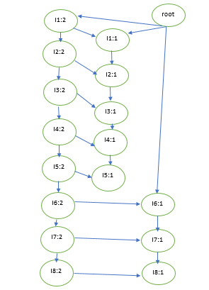

#### Question 3a

(1 point) How many frequent patterns exist?

The frequency pattern is 2^8 - 1 = 255.

#### Question 3b

(3 points) What is the set of frequent closed patterns?

Closed set: <I1,I2,I3,I4,I5> and <I6,I7,I8> are closed pattern.

#### Question 3c

(2 points) What is the set of frequent max-patterns?

The frequency max patterns is <I1, I2, I3, I4, I5, I6, I7, I8>.

#### Question 3d

(4 points) Find an example of an association rule that matches the following pattern with min-support = 2 and min-conf = 70

(I1, I2, I3, I4, IX -> IY )

Lets substitute IX = I7 and IY = I8

(I1,I2,I3,I4,I7 -> I8)

Above association satisify the conditions of support and confidence.

#### Question 3e

(8 points) For the association rule I1 -> I6, compute the support, confidence, lift, and interest

Support(I1) = 3 , Support(I1,I6) = 2, Support(I6) = 3

Conf = Support(I1,I6)/Support(I1) = 2/3 = 0.66

Interest = Lift(I1,I6)/P(I1)P(I6) = 0.22/{(3/5) * (3/5)} = 0.22/0.36 = 0.611

#### Question 4

**Data Mining Book: 6.6**

For each algorithm, show the major steps through the algorithm. Also, report at the end the frequent items sets identified.

#### Question 4a

(24 points) For Apriori, present Li and Ci for each level i considered

$$C_1$$

| Item set | sup |
| --- | --- |
| **{M}** | **3** |
| **{O}** | **3** |
| {N} | 2 |
| **{K}** | **5** |
| **{E}** | **4** |
| **{Y}** | **3** |
| {D} | 1 |
| {A} | 1 |
| {U} | 1 |
| {C} | 2 |
| {I} | 1 |

$$L_1$$

| Item set | sup |
| --- | --- |
| {M} | 3 |
| {O} | 3 |
| {K} | 5 |
| {E} | 4 |
| {Y} | 3 |

$$C_2$$

| Item set | sup |
| --- | --- |
| {M, O} | 1 |
| **{M, K}** | **3** |
| {M, E} | 2 |
| {M, Y} | 2 |
| **{O, K}** | **3** |
| **{O, E}** | **3** |
| {O, Y} | 2 |
| **{K, E}** | **4** |
| **{K, Y}** | **3** |
| {E, Y} | 2 |

$$L_2$$

| Item set | sup |
| --- | --- |
| {M, K} | 3 |
| {O, K} | 3 |
| {O, E} | 3 |
| {K, E} | 4 |
| {K, Y} | 3 |

$$C_3$$

| Item set | sup |
| --- | --- |
| {M, K, E} | 2 |
| {M, K, O} | 1 |
| {M, K, Y} | 2 |
| **{K, O, E}** | **3** |
| {O, K, Y} | 2 |
| {O, E, Y} | 2 |
| {K, E, Y} | 2 |

$$L_3$$

| Item set | sup |
| --- | --- |
| {K, O, E} | 3 |

#### Frequent Sets

- {M}
- {O}
- {K}
- {E}
- {Y}
- {M, K}
- {O, K}
- {O, E}
- {K, E}
- {K, Y}
- {K, O, E}

#### Question 4b

(22 points) For FP-growth, present the FP-tree like Fig. 6.7 (p. 258) and present the generated the frequent patterns like Table 6.2 (p. 259) (the conditional FP-trees do not need to be illustrated explicitly).

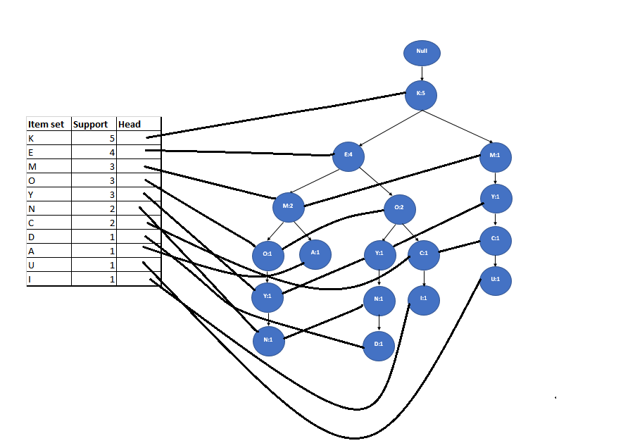

**Frequency Pattern**

[output not shown]

## Part 2: Use Software

For the first four problems you do not need to use R/Matlab/Python, rather this is showing you understand definitions, concepts, and how the algorithms work.

#### Question 5

(12 points) Confirm the results above of the Apriori algorithm. For R, the arules package is available or Matlab has the Association Rules package available from File Exchange.

```r
transactions <- read.transactions(file = "transaction.txt", rm.duplicates = FALSE,
                                  format = "basket", sep = ",")
inspect(transactions)
```

```
##     items
## [1] {E,K,M,N,O,Y}
## [2] {D,E,K,N,O,Y}
## [3] {A,E,K,M}
## [4] {C,K,M,U,Y}
## [5] {C,E,I,K,O}
```

```r
fsets <- eclat(transactions, parameter = list(supp = 0.6))
```

```
## Eclat
##
## parameter specification:
##  tidLists support minlen maxlen            target   ext
##     FALSE     0.6      1     10 frequent itemsets FALSE
##
## algorithmic control:
##  sparse sort verbose
##       7   -2    TRUE
##
## Absolute minimum support count: 3
##
## create itemset ...
## set transactions ...[11 item(s), 5 transaction(s)] done [0.00s].
## sorting and recoding items ... [5 item(s)] done [0.00s].
## creating bit matrix ... [5 row(s), 5 column(s)] done [0.00s].
## writing  ... [11 set(s)] done [0.00s].
## Creating S4 object  ... done [0.00s].
```

```r
inspect(fsets)
```

```
##      items   support
## [1]  {K,M}   0.6
## [2]  {K,Y}   0.6
## [3]  {E,K,O} 0.6
## [4]  {K,O}   0.6
## [5]  {E,O}   0.6
## [6]  {E,K}   0.8
## [7]  {K}     1.0
## [8]  {E}     0.8
## [9]  {O}     0.6
## [10] {Y}     0.6
## [11] {M}     0.6
```

**End of the assignment**